# Niveau d’instruction et utilisation des contraceptifs chez les femmes de 15-49 ans au MALI

joseph

2025-10-08

# Introduction

Au Mali, la planification familiale constitue un enjeu majeur de santé publique. Bien que la prévalence contraceptive ait légèrement augmenté entre 2001 et 2012, elle reste parmi les plus faibles de la région. Les écarts observés entre milieux urbains et ruraux, niveaux d’instruction et statuts socio-économiques suggèrent que l’éducation pourrait jouer un rôle déterminant dans l’adoption des méthodes contraceptives. Cette étude vise à explorer cette relation à l’aide d’analyses statistiques descriptives sous R.

# Objectifs

## Objectif général :

decrire l’influence du niveau d’instruction sur l’utilisation des contraceptifs chez les femmes maliennes âgées de 15 à 49 ans.

## Objectifs spécifiques :

- Décrire la prévalence de l’utilisation des contraceptifs selon les caractéristiques sociodémographiques.
- Examiner la relation entre le niveau d’instruction et l’utilisation des contraceptifs.

# Methodologie

L’étude repose sur une analyse descriptive transversale des données de l’EDS-Mali 2014, portant sur les femmes âgées de 15 à 49 ans. La variable dépendante est l’utilisation des contraceptifs (oui/non), et les principales variables explicatives incluent: - le niveau d’instruction, - l’âge, - le milieu de résidence, - la région, - connaissance methode contraceptive, - methode contraceptive actuelle.

Les analyses descriptives seront réalisées sous R, à l’aide de statistiques de fréquence, de tableaux croisés et de graphiques pour décrire la prévalence de l’utilisation des contraceptifs selon les caractéristiques sociodémographiques.

# Resultats

## *Prevalence de l’utilisation des contraceptifs par region*

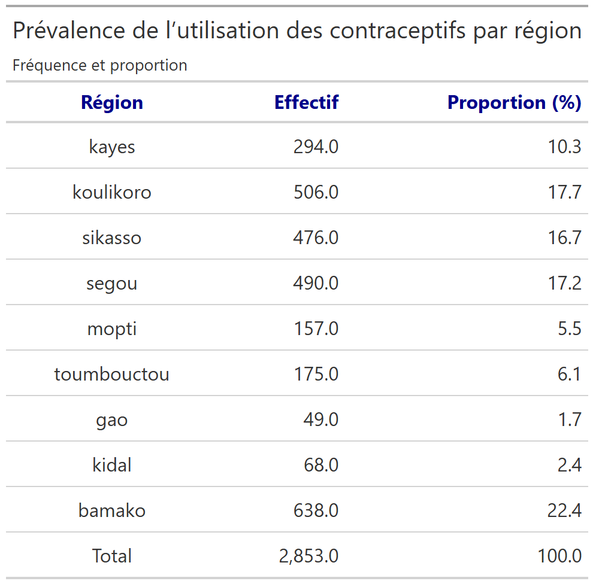

## *Répartition des femmes par tranche d’âge*

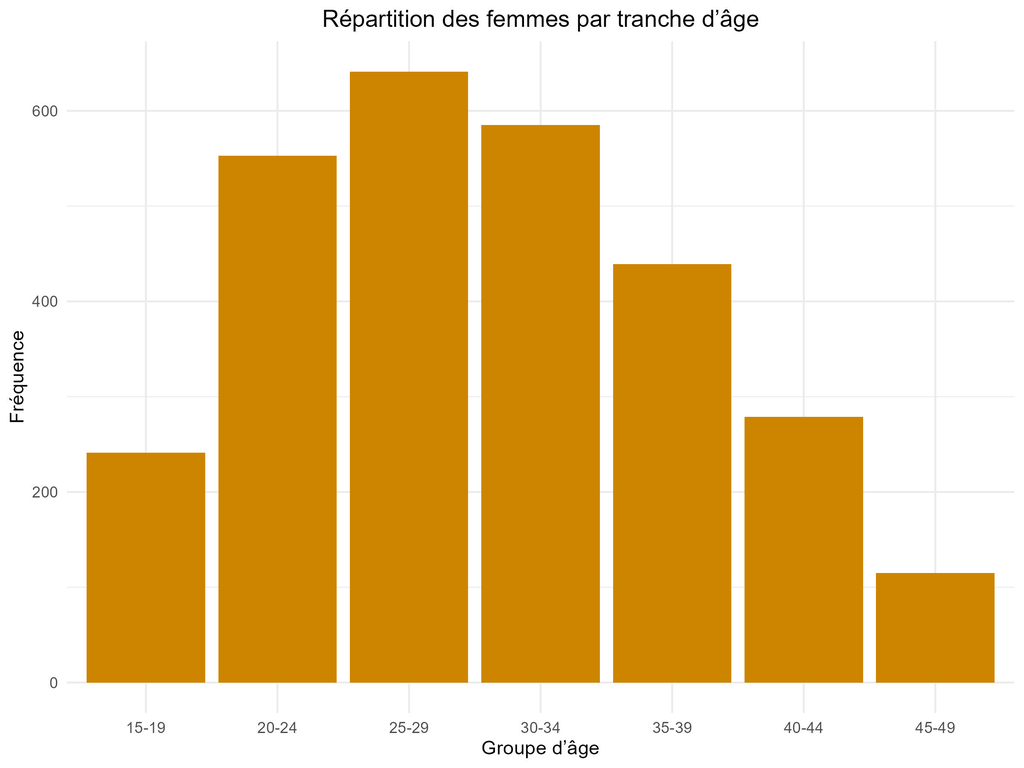